# Thesis Analysis: National Survey (Aug 3-9, 2020)

Nate Bender

5/4/2021

# Setup / EDA

After filtering the 383 rejected respondents, we’re left with 1055 valid respondents in the dataset.

Gender breakdown of respondents is as follows:

```
##   female femalepercent male malepercent other otherpercent noanswer
## 1    520     0.3182375  499   0.3053856     4   0.00244798       26
##   noanswerpercent total
## 1      0.01591187  1049
```

# Principal Components Analysis

$$\\[.05in]$$
### Dynamic Norms *“Do you think that over the PAST/NEXT 12 months the percentage of adults in the United States who contacted elected officials to urge them to take action to reduce global warming is…”*

One factor solution:  
1. Two-item factor consisting of the two dynamic norms questions (changes in the number of ppl contacting reps in the past and future)

```
##
##  Spearman's rank correlation rho
##
## data:  d_accept$sr_24_past_contact and d_accept$sr_25_future_contact
## S = 55659844, p-value < 2.2e-16
## alternative hypothesis: true rho is not equal to 0
## sample estimates:
##       rho
## 0.7115133
```

Correlation test of the two dynamic norms items shows strong positive correlation, with Spearman’s rho of 0.7115133 and p-value of 8.634289710^{-163}.

$$\\[.05in]$$

### Descriptive Norms (contact)

*“To what extent do you think that the following people ARE CONTACTING (writing letters, emailing, or calling) their elected representatives in Congress to urge action on reducing climate change?”*

Three factor solution (70% cumulative variance (hereafter: cv))  
1. 1-item variable: Parents  
2. 2-item composite variable: Spouse, Children  
3. Multi-item composite variable: Non-immediate family

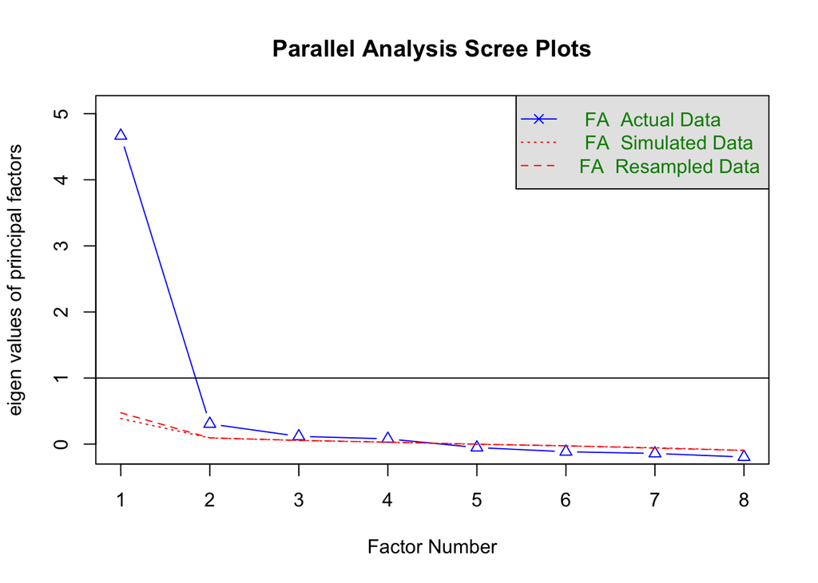

```
## Parallel analysis suggests that the number of factors =  4  and the number of components =  NA
```

```
## Factor Analysis using method =  minres
## Call: fa(r = d_pca_descriptivecontactnorms, nfactors = 4, rotate = "Varimax",
##     fm = "minres")
## Standardized loadings (pattern matrix) based upon correlation matrix
##                                          MR1  MR3  MR2   MR4   h2     u2 com
## sr_19a_contacting_officials__parents    0.25 0.19 0.94  0.09 1.00 0.0047 1.2
## sr_19b_contacting_officials_spouse      0.34 0.60 0.33  0.07 0.59 0.4062 2.2
## sr_19c_contacting_officials_children    0.29 0.77 0.22  0.16 0.75 0.2455 1.6
## sr_19d_contacting_officials_otherfamily 0.65 0.43 0.34 -0.02 0.72 0.2822 2.3
## sr_19e_contacting_officials_friends     0.84 0.25 0.25  0.09 0.85 0.1517 1.4
## sr_19f_contacting_officials_coworkers   0.60 0.21 0.37  0.37 0.68 0.3214 2.7
## sr_19g_contacting_officials_recpartners 0.75 0.28 0.25  0.28 0.78 0.2178 1.8
## sr_19h_contacting_officials_faithcommun 0.46 0.45 0.22  0.46 0.67 0.3272 3.4
##
##                        MR1  MR3  MR2  MR4
## SS loadings           2.54 1.56 1.48 0.47
## Proportion Var        0.32 0.20 0.19 0.06
## Cumulative Var        0.32 0.51 0.70 0.76
## Proportion Explained  0.42 0.26 0.24 0.08
## Cumulative Proportion 0.42 0.68 0.92 1.00
##
## Mean item complexity =  2.1
## Test of the hypothesis that 4 factors are sufficient.
##
## The degrees of freedom for the null model are  28  and the objective function was  5.2 with Chi Square of  5461.43
## The degrees of freedom for the model are 2  and the objective function was  0.02
##
## The root mean square of the residuals (RMSR) is  0.01
## The df corrected root mean square of the residuals is  0.03
##
## The harmonic number of observations is  1047 with the empirical chi square  2.85  with prob <  0.24
## The total number of observations was  1055  with Likelihood Chi Square =  19.2  with prob <  6.8e-05
##
## Tucker Lewis Index of factoring reliability =  0.956
## RMSEA index =  0.09  and the 90 % confidence intervals are  0.056 0.129
## BIC =  5.28
## Fit based upon off diagonal values = 1
## Measures of factor score adequacy
##                                                    MR1  MR3  MR2   MR4
## Correlation of (regression) scores with factors   0.91 0.84 0.99  0.66
## Multiple R square of scores with factors          0.83 0.71 0.98  0.44
## Minimum correlation of possible factor scores     0.67 0.43 0.97 -0.13
```

```
##
## Loadings:
##                                         MR1    MR3    MR2    MR4
## sr_19a_contacting_officials__parents                   0.945
## sr_19b_contacting_officials_spouse       0.341  0.602  0.332
## sr_19c_contacting_officials_children            0.771
## sr_19d_contacting_officials_otherfamily  0.649  0.427  0.339
## sr_19e_contacting_officials_friends      0.844
## sr_19f_contacting_officials_coworkers    0.604         0.369  0.369
## sr_19g_contacting_officials_recpartners  0.750
## sr_19h_contacting_officials_faithcommun  0.462  0.450         0.457
##
##                  MR1   MR3   MR2   MR4
## SS loadings    2.536 1.562 1.480 0.465
## Proportion Var 0.317 0.195 0.185 0.058
## Cumulative Var 0.317 0.512 0.697 0.755
```

#### Descriptive Norms (contact) - 1st factor (Parents) - desc stats

```r
mean(d_accept$sr_19a_contacting_officials__parents, na.rm=TRUE)
```

```
## [1] 2.535104
```

```r
sd(d_accept$sr_19a_contacting_officials__parents, na.rm=TRUE)
```

```
## [1] 1.743854
```

```r
summary(d_pca_descriptivecontactnorms)
```

```
##  sr_19a_contacting_officials__parents sr_19b_contacting_officials_spouse
##  Min.   :1.000                        Min.   :1.000
##  1st Qu.:1.000                        1st Qu.:1.000
##  Median :1.000                        Median :1.000
##  Mean   :2.535                        Mean   :2.443
##  3rd Qu.:5.000                        3rd Qu.:4.000
##  Max.   :5.000                        Max.   :5.000
##  NA's   :1                            NA's   :2
##  sr_19c_contacting_officials_children sr_19d_contacting_officials_otherfamily
##  Min.   :1.00                         Min.   :1.000
##  1st Qu.:1.00                         1st Qu.:1.000
##  Median :2.00                         Median :1.000
##  Mean   :2.72                         Mean   :2.254
##  3rd Qu.:5.00                         3rd Qu.:3.000
##  Max.   :5.00                         Max.   :5.000
##  NA's   :7                            NA's   :4
##  sr_19e_contacting_officials_friends sr_19f_contacting_officials_coworkers
##  Min.   :1.000                       Min.   :1.00
##  1st Qu.:1.000                       1st Qu.:1.00
##  Median :2.000                       Median :2.00
##  Mean   :2.343                       Mean   :2.67
##  3rd Qu.:3.000                       3rd Qu.:5.00
##  Max.   :5.000                       Max.   :5.00
##  NA's   :3                           NA's   :6
##  sr_19g_contacting_officials_recpartners
##  Min.   :1.000
##  1st Qu.:1.000
##  Median :2.000
##  Mean   :2.423
##  3rd Qu.:4.000
##  Max.   :5.000
##  NA's   :5
##  sr_19h_contacting_officials_faithcommun
##  Min.   :1.000
##  1st Qu.:1.000
##  Median :3.000
##  Mean   :2.784
##  3rd Qu.:5.000
##  Max.   :5.000
##  NA's   :5
```

```r
sapply(d_pca_descriptivecontactnorms, sd, na.rm=TRUE)
```

```
##    sr_19a_contacting_officials__parents      sr_19b_contacting_officials_spouse
##                                1.743854                                1.680738
##    sr_19c_contacting_officials_children sr_19d_contacting_officials_otherfamily
##                                1.743067                                1.553849
##     sr_19e_contacting_officials_friends   sr_19f_contacting_officials_coworkers
##                                1.505183                                1.695829
## sr_19g_contacting_officials_recpartners sr_19h_contacting_officials_faithcommun
##                                1.608560                                1.726793
```

#### Descriptive Norms (contact) - 2nd factor (Spouse & Children) - Correlation & desc stats

```
##
##  Spearman's rank correlation rho
##
## data:  d_accept$sr_19b_contacting_officials_spouse and d_accept$sr_19c_contacting_officials_children
## S = 66750321, p-value < 2.2e-16
## alternative hypothesis: true rho is not equal to 0
## sample estimates:
##       rho
## 0.6500468
```

Correlation test of the two descriptive norms items for Spouse and Children, showing moderate positive correlation. Spearman’s rho is 0.6500468 with a p-value of 1.216809610^{-126}.

#### Descriptive Norms (contact) - 3rd factor (Non-immediate family) - Cronbach Alpha

```
##
## Reliability analysis
## Call: psych::alpha(x = d_pca_descriptivecontactnormsnonfamily, na.rm = TRUE,
##     use = "pairwise")
##
##   raw_alpha std.alpha G6(smc) average_r S/N    ase mean  sd median_r
##       0.91      0.91     0.9      0.66 9.9 0.0046  2.5 1.4     0.66
##
##  lower alpha upper     95% confidence boundaries
## 0.9 0.91 0.92
##
##  Reliability if an item is dropped:
##                                         raw_alpha std.alpha G6(smc) average_r
## sr_19d_contacting_officials_otherfamily      0.89      0.89    0.87      0.68
## sr_19e_contacting_officials_friends          0.87      0.88    0.84      0.64
## sr_19f_contacting_officials_coworkers        0.89      0.89    0.87      0.67
## sr_19g_contacting_officials_recpartners      0.87      0.87    0.85      0.64
## sr_19h_contacting_officials_faithcommun      0.90      0.90    0.88      0.70
##                                         S/N alpha se  var.r med.r
## sr_19d_contacting_officials_otherfamily 8.4   0.0055 0.0049  0.67
## sr_19e_contacting_officials_friends     7.0   0.0063 0.0031  0.64
## sr_19f_contacting_officials_coworkers   8.1   0.0057 0.0080  0.66
## sr_19g_contacting_officials_recpartners 7.0   0.0065 0.0045  0.62
## sr_19h_contacting_officials_faithcommun 9.4   0.0049 0.0041  0.69
##
##  Item statistics
##                                            n raw.r std.r r.cor r.drop mean  sd
## sr_19d_contacting_officials_otherfamily 1051  0.83  0.84  0.78   0.74  2.3 1.6
## sr_19e_contacting_officials_friends     1052  0.89  0.89  0.88   0.82  2.3 1.5
## sr_19f_contacting_officials_coworkers   1049  0.85  0.85  0.79   0.76  2.7 1.7
## sr_19g_contacting_officials_recpartners 1050  0.89  0.90  0.88   0.83  2.4 1.6
## sr_19h_contacting_officials_faithcommun 1050  0.81  0.80  0.72   0.69  2.8 1.7
##
## Non missing response frequency for each item
##                                            1    2    3    4    5 miss
## sr_19d_contacting_officials_otherfamily 0.53 0.11 0.13 0.07 0.17 0.00
## sr_19e_contacting_officials_friends     0.45 0.16 0.14 0.08 0.16 0.00
## sr_19f_contacting_officials_coworkers   0.42 0.12 0.12 0.06 0.28 0.01
## sr_19g_contacting_officials_recpartners 0.47 0.12 0.12 0.07 0.21 0.00
## sr_19h_contacting_officials_faithcommun 0.40 0.09 0.13 0.06 0.31 0.00
```

$$\\[.05in]$$

### Descriptive Norms (role models)

*“How likely are you to consider each of these groups as behavioral role models?”*

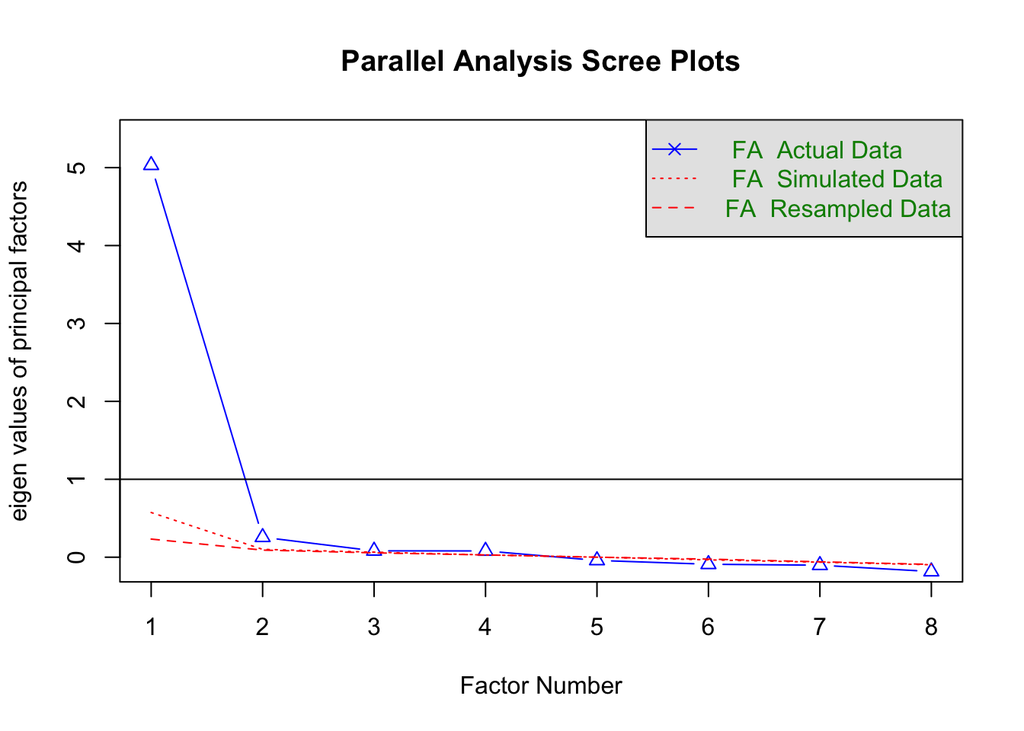

[output not shown]

```
## Factor Analysis using method =  minres
## Call: fa(r = d_pca_descriptiverolemodelnorms, nfactors = 4, rotate = "Varimax",
##     fm = "minres")
## Standardized loadings (pattern matrix) based upon correlation matrix
##                                MR1  MR3  MR2  MR4   h2     u2 com
## sr_20a_rolemodels_parents     0.25 0.22 0.93 0.11 1.00 0.0035 1.3
## sr_20b_rolemodels_spouse      0.37 0.61 0.38 0.11 0.67 0.3301 2.5
## sr_20c_rolemodels_children    0.35 0.80 0.26 0.15 0.85 0.1505 1.7
## sr_20d_rolemodels_otherfamily 0.67 0.35 0.35 0.15 0.72 0.2802 2.2
## sr_20e_rolemodels_friends     0.87 0.30 0.26 0.11 0.92 0.0775 1.5
## sr_20f_rolemodels_coworkers   0.50 0.28 0.37 0.45 0.67 0.3274 3.5
## sr_20g_rolemodels_recpartners 0.66 0.33 0.27 0.40 0.78 0.2152 2.6
## sr_20h_rolemodels_faithcommun 0.43 0.49 0.26 0.38 0.63 0.3704 3.5
##
##                        MR1  MR3  MR2  MR4
## SS loadings           2.39 1.70 1.55 0.59
## Proportion Var        0.30 0.21 0.19 0.07
## Cumulative Var        0.30 0.51 0.71 0.78
## Proportion Explained  0.38 0.27 0.25 0.10
## Cumulative Proportion 0.38 0.66 0.90 1.00
##
## Mean item complexity =  2.3
## Test of the hypothesis that 4 factors are sufficient.
##
## The degrees of freedom for the null model are  28  and the objective function was  5.89 with Chi Square of  6186.7
## The degrees of freedom for the model are 2  and the objective function was  0.01
##
## The root mean square of the residuals (RMSR) is  0.01
## The df corrected root mean square of the residuals is  0.02
##
## The harmonic number of observations is  1046 with the empirical chi square  1.79  with prob <  0.41
## The total number of observations was  1055  with Likelihood Chi Square =  14.8  with prob <  0.00061
##
## Tucker Lewis Index of factoring reliability =  0.971
## RMSEA index =  0.078  and the 90 % confidence intervals are  0.044 0.117
## BIC =  0.88
## Fit based upon off diagonal values = 1
## Measures of factor score adequacy
##                                                    MR1  MR3  MR2   MR4
## Correlation of (regression) scores with factors   0.93 0.88 0.99  0.68
## Multiple R square of scores with factors          0.86 0.77 0.98  0.46
## Minimum correlation of possible factor scores     0.73 0.53 0.97 -0.09
```

```
##
## Loadings:
##                               MR1   MR3   MR2   MR4
## sr_20a_rolemodels_parents                 0.934
## sr_20b_rolemodels_spouse      0.367 0.612 0.384
## sr_20c_rolemodels_children    0.346 0.798
## sr_20d_rolemodels_otherfamily 0.672 0.354 0.346
## sr_20e_rolemodels_friends     0.866 0.303
## sr_20f_rolemodels_coworkers   0.502       0.372 0.452
## sr_20g_rolemodels_recpartners 0.664 0.330       0.400
## sr_20h_rolemodels_faithcommun 0.428 0.487       0.379
##
##                  MR1   MR3   MR2   MR4
## SS loadings    2.395 1.703 1.554 0.594
## Proportion Var 0.299 0.213 0.194 0.074
## Cumulative Var 0.299 0.512 0.706 0.781
```

#### Descriptive Norms (role models) - 1st factor (Parents) - Descriptive stats

```
## [1] 4.002852
```

```
## [1] 1.708264
```

#### Descriptive Norms (role models) - 2nd factor (Spouse & Children) - Correlation

```
##
##  Spearman's rank correlation rho
##
## data:  d_accept$sr_20b_rolemodels_spouse and d_accept$sr_20c_rolemodels_children
## S = 57601474, p-value < 2.2e-16
## alternative hypothesis: true rho is not equal to 0
## sample estimates:
##       rho
## 0.7023012
```

```
## [1] 4.009506
```

```
## [1] 1.642648
```

```
## [1] 4.060779
```

```
## [1] 1.727685
```

Correlation test of the two descriptive norms items for Spouse and Children, showing moderate positive correlation. Spearman’s rho is 0.7023012 with a p-value of 5.238168210^{-157}.

#### Descriptive Norms (role models) - 3rd factor (Non-immediate family) - Cronbach Alpha

```
##
## Reliability analysis
## Call: psych::alpha(x = d_pca_descriptiverolemodelnormsnonfamily, na.rm = TRUE,
##     use = "pairwise")
##
##   raw_alpha std.alpha G6(smc) average_r S/N    ase mean  sd median_r
##       0.91      0.92     0.9      0.68  11 0.0043  3.6 1.4     0.67
##
##  lower alpha upper     95% confidence boundaries
## 0.9 0.91 0.92
##
##  Reliability if an item is dropped:
##                               raw_alpha std.alpha G6(smc) average_r  S/N
## sr_20d_rolemodels_otherfamily      0.89      0.89    0.87      0.68  8.5
## sr_20e_rolemodels_friends          0.88      0.89    0.86      0.66  7.7
## sr_20f_rolemodels_coworkers        0.90      0.90    0.88      0.70  9.4
## sr_20g_rolemodels_recpartners      0.88      0.89    0.86      0.66  7.7
## sr_20h_rolemodels_faithcommun      0.91      0.91    0.89      0.72 10.3
##                               alpha se  var.r med.r
## sr_20d_rolemodels_otherfamily   0.0055 0.0039  0.67
## sr_20e_rolemodels_friends       0.0059 0.0024  0.65
## sr_20f_rolemodels_coworkers     0.0051 0.0067  0.69
## sr_20g_rolemodels_recpartners   0.0060 0.0052  0.63
## sr_20h_rolemodels_faithcommun   0.0046 0.0043  0.71
##
##  Item statistics
##                                  n raw.r std.r r.cor r.drop mean  sd
## sr_20d_rolemodels_otherfamily 1047  0.86  0.87  0.83   0.79  3.5 1.6
## sr_20e_rolemodels_friends     1051  0.89  0.90  0.88   0.83  3.5 1.5
## sr_20f_rolemodels_coworkers   1052  0.85  0.84  0.78   0.75  3.7 1.7
## sr_20g_rolemodels_recpartners 1046  0.90  0.90  0.88   0.83  3.5 1.6
## sr_20h_rolemodels_faithcommun 1045  0.82  0.81  0.74   0.71  4.0 1.8
##
## Non missing response frequency for each item
##                                  1    2    3    4    5    6 miss
## sr_20d_rolemodels_otherfamily 0.16 0.07 0.30 0.22 0.11 0.15 0.01
## sr_20e_rolemodels_friends     0.15 0.06 0.29 0.25 0.12 0.12 0.00
## sr_20f_rolemodels_coworkers   0.16 0.07 0.27 0.16 0.07 0.26 0.00
## sr_20g_rolemodels_recpartners 0.16 0.07 0.32 0.17 0.09 0.19 0.01
## sr_20h_rolemodels_faithcommun 0.15 0.05 0.23 0.15 0.12 0.30 0.01
```

[output not shown]

[output not shown]

$$\\[.05in]$$

### Injunctive Norms (contact)

*“To what extent do you think that the following people EXPECT YOU to contact (writing letters, emailing, or calling) your elected representatives to urge action on reducing climate change?”*

Scree plot suggests four factors (78% cv) but three (73% cv) makes the most sense.  
Three-factor solution:  
1. 1-item variable: Parents  
2. 2-item composite variable: Spouse, Children  
3. Multi-item composite variable: Non-immediate family

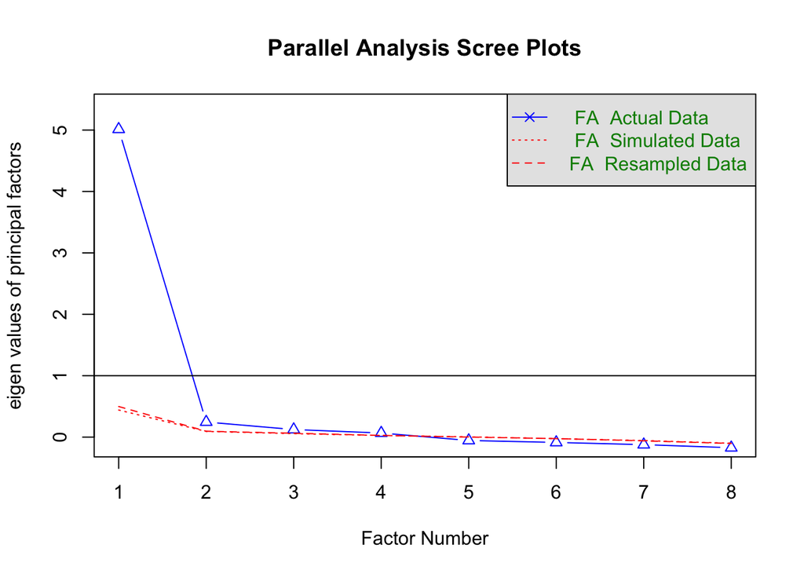

```
## Parallel analysis suggests that the number of factors =  4  and the number of components =  NA
```

```
## Factor Analysis using method =  minres
## Call: fa(r = d_pca_injunctivecontactnorms, nfactors = 4, rotate = "Varimax",
##     fm = "minres")
## Standardized loadings (pattern matrix) based upon correlation matrix
##                                    MR1  MR3  MR2  MR4   h2     u2 com
## sr_22a_expect_contact_parents     0.28 0.18 0.94 0.08 1.00 0.0044 1.3
## sr_22b_expect_contact_spouse      0.47 0.58 0.29 0.07 0.65 0.3511 2.5
## sr_22c_expect_contact_children    0.33 0.78 0.23 0.13 0.78 0.2207 1.6
## sr_22d_expect_contact_otherfamily 0.76 0.35 0.34 0.05 0.82 0.1789 1.8
## sr_22e_expect_contact_friends     0.89 0.25 0.27 0.11 0.94 0.0555 1.4
## sr_22f_expect_contact_coworkers   0.52 0.28 0.41 0.36 0.65 0.3482 3.3
## sr_22g_expect_contact_recpartners 0.72 0.32 0.27 0.31 0.79 0.2072 2.1
## sr_22h_expect_contact_faithcommun 0.44 0.47 0.24 0.40 0.63 0.3713 3.5
##
##                        MR1  MR3  MR2  MR4
## SS loadings           2.77 1.56 1.51 0.43
## Proportion Var        0.35 0.19 0.19 0.05
## Cumulative Var        0.35 0.54 0.73 0.78
## Proportion Explained  0.44 0.25 0.24 0.07
## Cumulative Proportion 0.44 0.69 0.93 1.00
##
## Mean item complexity =  2.2
## Test of the hypothesis that 4 factors are sufficient.
##
## The degrees of freedom for the null model are  28  and the objective function was  6.13 with Chi Square of  6444.2
## The degrees of freedom for the model are 2  and the objective function was  0.01
##
## The root mean square of the residuals (RMSR) is  0
## The df corrected root mean square of the residuals is  0.01
##
## The harmonic number of observations is  1047 with the empirical chi square  0.8  with prob <  0.67
## The total number of observations was  1055  with Likelihood Chi Square =  7.01  with prob <  0.03
##
## Tucker Lewis Index of factoring reliability =  0.989
## RMSEA index =  0.049  and the 90 % confidence intervals are  0.013 0.09
## BIC =  -6.92
## Fit based upon off diagonal values = 1
## Measures of factor score adequacy
##                                                    MR1  MR3  MR2   MR4
## Correlation of (regression) scores with factors   0.95 0.85 0.99  0.63
## Multiple R square of scores with factors          0.90 0.72 0.99  0.39
## Minimum correlation of possible factor scores     0.81 0.45 0.97 -0.21
```

```
##
## Loadings:
##                                   MR1   MR3   MR2   MR4
## sr_22a_expect_contact_parents                 0.937
## sr_22b_expect_contact_spouse      0.470 0.581
## sr_22c_expect_contact_children    0.326 0.778
## sr_22d_expect_contact_otherfamily 0.763 0.346 0.341
## sr_22e_expect_contact_friends     0.891
## sr_22f_expect_contact_coworkers   0.524       0.411 0.361
## sr_22g_expect_contact_recpartners 0.724 0.316       0.306
## sr_22h_expect_contact_faithcommun 0.438 0.467       0.402
##
##                  MR1   MR3   MR2   MR4
## SS loadings    2.771 1.556 1.507 0.429
## Proportion Var 0.346 0.194 0.188 0.054
## Cumulative Var 0.346 0.541 0.729 0.783
```

```
##  sr_22a_expect_contact_parents sr_22b_expect_contact_spouse
##  Min.   :1.000                 Min.   :1.0
##  1st Qu.:1.000                 1st Qu.:1.0
##  Median :3.000                 Median :3.0
##  Mean   :2.914                 Mean   :2.8
##  3rd Qu.:5.000                 3rd Qu.:5.0
##  Max.   :5.000                 Max.   :5.0
##  NA's   :5                     NA's   :3
##  sr_22c_expect_contact_children sr_22d_expect_contact_otherfamily
##  Min.   :1.000                  Min.   :1.000
##  1st Qu.:1.000                  1st Qu.:1.000
##  Median :3.000                  Median :2.000
##  Mean   :3.001                  Mean   :2.457
##  3rd Qu.:5.000                  3rd Qu.:4.000
##  Max.   :5.000                  Max.   :5.000
##  NA's   :8                      NA's   :5
##  sr_22e_expect_contact_friends sr_22f_expect_contact_coworkers
##  Min.   :1.00                  Min.   :1.000
##  1st Qu.:1.00                  1st Qu.:1.000
##  Median :2.00                  Median :3.000
##  Mean   :2.45                  Mean   :2.792
##  3rd Qu.:4.00                  3rd Qu.:5.000
##  Max.   :5.00                  Max.   :5.000
##  NA's   :6                     NA's   :3
##  sr_22g_expect_contact_recpartners sr_22h_expect_contact_faithcommun
##  Min.   :1.000                     Min.   :1.000
##  1st Qu.:1.000                     1st Qu.:1.000
##  Median :2.000                     Median :3.000
##  Mean   :2.553                     Mean   :3.011
##  3rd Qu.:4.000                     3rd Qu.:5.000
##  Max.   :5.000                     Max.   :5.000
##  NA's   :6                         NA's   :4
```

```
##     sr_22a_expect_contact_parents      sr_22b_expect_contact_spouse
##                          1.719702                          1.675388
##    sr_22c_expect_contact_children sr_22d_expect_contact_otherfamily
##                          1.684197                          1.560527
##     sr_22e_expect_contact_friends   sr_22f_expect_contact_coworkers
##                          1.545624                          1.675198
## sr_22g_expect_contact_recpartners sr_22h_expect_contact_faithcommun
##                          1.593556                          1.702061
```

#### Injunctive Norms (contact) - 2nd factor (Spouse & Children) - Correlation

```
##
##  Spearman's rank correlation rho
##
## data:  d_accept$sr_22b_expect_contact_spouse and d_accept$sr_22c_expect_contact_children
## S = 59666822, p-value < 2.2e-16
## alternative hypothesis: true rho is not equal to 0
## sample estimates:
##       rho
## 0.6862847
```

Correlation test of the two descriptive norms items for Spouse and Children, showing moderate positive correlation. Spearman’s rho is 0.6862847 with a p-value of 2.205706710^{-146}.

#### Injunctive Norms (contact) - 3rd factor (Non-family) - Cronbach Alpha

```
##
## Reliability analysis
## Call: psych::alpha(x = d_pca_injunctivecontactnormsnonfamily, na.rm = TRUE,
##     use = "pairwise")
##
##   raw_alpha std.alpha G6(smc) average_r S/N    ase mean  sd median_r
##       0.92      0.92    0.91       0.7  12 0.0041  2.7 1.4     0.67
##
##  lower alpha upper     95% confidence boundaries
## 0.91 0.92 0.93
##
##  Reliability if an item is dropped:
##                                   raw_alpha std.alpha G6(smc) average_r  S/N
## sr_22d_expect_contact_otherfamily      0.89      0.90    0.88      0.68  8.6
## sr_22e_expect_contact_friends          0.89      0.89    0.86      0.66  7.8
## sr_22f_expect_contact_coworkers        0.91      0.91    0.90      0.72 10.5
## sr_22g_expect_contact_recpartners      0.89      0.89    0.88      0.67  8.2
## sr_22h_expect_contact_faithcommun      0.92      0.92    0.91      0.75 12.1
##                                   alpha se  var.r med.r
## sr_22d_expect_contact_otherfamily   0.0054 0.0066  0.67
## sr_22e_expect_contact_friends       0.0058 0.0042  0.65
## sr_22f_expect_contact_coworkers     0.0047 0.0132  0.71
## sr_22g_expect_contact_recpartners   0.0057 0.0105  0.64
## sr_22h_expect_contact_faithcommun   0.0040 0.0073  0.73
##
##  Item statistics
##                                      n raw.r std.r r.cor r.drop mean  sd
## sr_22d_expect_contact_otherfamily 1050  0.89  0.89  0.88   0.82  2.5 1.6
## sr_22e_expect_contact_friends     1049  0.92  0.92  0.92   0.87  2.4 1.5
## sr_22f_expect_contact_coworkers   1052  0.84  0.84  0.77   0.74  2.8 1.7
## sr_22g_expect_contact_recpartners 1049  0.91  0.91  0.89   0.85  2.6 1.6
## sr_22h_expect_contact_faithcommun 1051  0.80  0.80  0.71   0.69  3.0 1.7
##
## Non missing response frequency for each item
##                                      1    2    3    4    5 miss
## sr_22d_expect_contact_otherfamily 0.44 0.12 0.17 0.08 0.19 0.00
## sr_22e_expect_contact_friends     0.43 0.14 0.17 0.08 0.19 0.01
## sr_22f_expect_contact_coworkers   0.37 0.11 0.15 0.07 0.29 0.00
## sr_22g_expect_contact_recpartners 0.41 0.13 0.16 0.07 0.22 0.01
## sr_22h_expect_contact_faithcommun 0.34 0.09 0.15 0.08 0.35 0.00
```

$$\\[.05in]$$

### Injunctive Norms (compliance)

*“How motivated are you to comply with the expectations of each of these people?”*

Two factor solution (70% cv)  
1. Multi-item composite variable: Parents, Spouse, Children  
2. Multi-item composite variable: Otherfam, Friends, Cowork, Recpartners, Faith

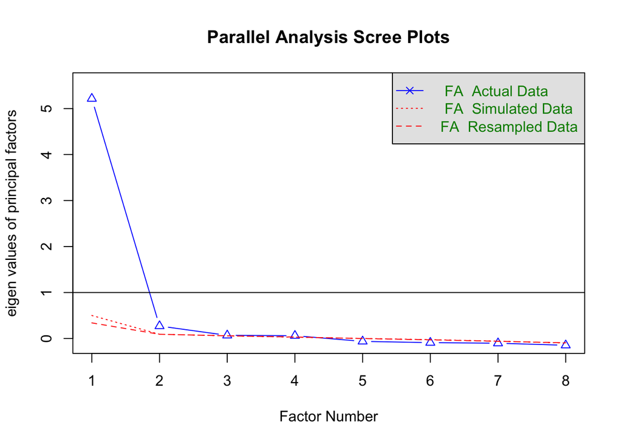

```
## Parallel analysis suggests that the number of factors =  2  and the number of components =  NA
```

```
## Factor Analysis using method =  minres
## Call: fa(r = d_pca_injunctivecompliance, nfactors = 2, rotate = "Varimax",
##     fm = "minres")
## Standardized loadings (pattern matrix) based upon correlation matrix
##                                         MR1  MR2   h2   u2 com
## sr_23a_motivated_to_comply_parents     0.48 0.52 0.50 0.50 2.0
## sr_23b_motivated_to_comply_spouse      0.41 0.78 0.77 0.23 1.5
## sr_23c_motivated_to_comply_children    0.44 0.69 0.68 0.32 1.7
## sr_23d_motivated_to_comply_otherfamily 0.79 0.42 0.79 0.21 1.5
## sr_23e_motivated_to_comply_friends     0.83 0.36 0.82 0.18 1.4
## sr_23f_motivated_to_comply_coworkers   0.71 0.40 0.66 0.34 1.6
## sr_23g_motivated_to_comply_recpartners 0.83 0.36 0.82 0.18 1.4
## sr_23h_motivated_to_comply_faithcommun 0.57 0.50 0.58 0.42 2.0
##
##                        MR1  MR2
## SS loadings           3.43 2.20
## Proportion Var        0.43 0.28
## Cumulative Var        0.43 0.70
## Proportion Explained  0.61 0.39
## Cumulative Proportion 0.61 1.00
##
## Mean item complexity =  1.6
## Test of the hypothesis that 2 factors are sufficient.
##
## The degrees of freedom for the null model are  28  and the objective function was  6.43 with Chi Square of  6749.49
## The degrees of freedom for the model are 13  and the objective function was  0.15
##
## The root mean square of the residuals (RMSR) is  0.02
## The df corrected root mean square of the residuals is  0.03
##
## The harmonic number of observations is  1049 with the empirical chi square  30.86  with prob <  0.0035
## The total number of observations was  1055  with Likelihood Chi Square =  161.82  with prob <  8.5e-28
##
## Tucker Lewis Index of factoring reliability =  0.952
## RMSEA index =  0.104  and the 90 % confidence intervals are  0.09 0.119
## BIC =  71.32
## Fit based upon off diagonal values = 1
## Measures of factor score adequacy
##                                                    MR1  MR2
## Correlation of (regression) scores with factors   0.92 0.85
## Multiple R square of scores with factors          0.84 0.72
## Minimum correlation of possible factor scores     0.68 0.45
```

```
##
## Loadings:
##                                        MR1   MR2
## sr_23a_motivated_to_comply_parents     0.480 0.521
## sr_23b_motivated_to_comply_spouse      0.412 0.778
## sr_23c_motivated_to_comply_children    0.441 0.694
## sr_23d_motivated_to_comply_otherfamily 0.788 0.417
## sr_23e_motivated_to_comply_friends     0.832 0.357
## sr_23f_motivated_to_comply_coworkers   0.705 0.402
## sr_23g_motivated_to_comply_recpartners 0.834 0.358
## sr_23h_motivated_to_comply_faithcommun 0.573 0.504
##
##                  MR1   MR2
## SS loadings    3.430 2.203
## Proportion Var 0.429 0.275
## Cumulative Var 0.429 0.704
```

```
##  sr_23a_motivated_to_comply_parents sr_23b_motivated_to_comply_spouse
##  Min.   :1.000                      Min.   :1.000
##  1st Qu.:4.000                      1st Qu.:4.000
##  Median :4.000                      Median :4.000
##  Mean   :4.968                      Mean   :4.976
##  3rd Qu.:8.000                      3rd Qu.:8.000
##  Max.   :8.000                      Max.   :8.000
##                                     NA's   :4
##  sr_23c_motivated_to_comply_children sr_23d_motivated_to_comply_otherfamily
##  Min.   :1.000                       Min.   :1.000
##  1st Qu.:4.000                       1st Qu.:3.000
##  Median :4.000                       Median :4.000
##  Mean   :5.115                       Mean   :4.287
##  3rd Qu.:8.000                       3rd Qu.:7.000
##  Max.   :8.000                       Max.   :8.000
##  NA's   :3                           NA's   :1
##  sr_23e_motivated_to_comply_friends sr_23f_motivated_to_comply_coworkers
##  Min.   :1.000                      Min.   :1.000
##  1st Qu.:3.000                      1st Qu.:4.000
##  Median :4.000                      Median :4.000
##  Mean   :4.288                      Mean   :4.695
##  3rd Qu.:5.500                      3rd Qu.:8.000
##  Max.   :8.000                      Max.   :8.000
##
##  sr_23g_motivated_to_comply_recpartners sr_23h_motivated_to_comply_faithcommun
##  Min.   :1.000                          Min.   :1.000
##  1st Qu.:3.000                          1st Qu.:4.000
##  Median :4.000                          Median :4.000
##  Mean   :4.446                          Mean   :5.017
##  3rd Qu.:7.000                          3rd Qu.:8.000
##  Max.   :8.000                          Max.   :8.000
##  NA's   :8                              NA's   :11
```

```
##     sr_23a_motivated_to_comply_parents      sr_23b_motivated_to_comply_spouse
##                               2.543531                               2.437486
##    sr_23c_motivated_to_comply_children sr_23d_motivated_to_comply_otherfamily
##                               2.501965                               2.292043
##     sr_23e_motivated_to_comply_friends   sr_23f_motivated_to_comply_coworkers
##                               2.240392                               2.497384
## sr_23g_motivated_to_comply_recpartners sr_23h_motivated_to_comply_faithcommun
##                               2.365038                               2.552552
```

#### Injunctive Norms (compliance) - 1st factor (Immediate Family) - Cronbach Alpha

```
##
## Reliability analysis
## Call: psych::alpha(x = d_pca_injunctivecompliancefamily, na.rm = TRUE,
##     use = "pairwise")
##
##   raw_alpha std.alpha G6(smc) average_r S/N    ase mean  sd median_r
##       0.84      0.84    0.78      0.63 5.1 0.0088    5 2.2     0.62
##
##  lower alpha upper     95% confidence boundaries
## 0.82 0.84 0.85
##
##  Reliability if an item is dropped:
##                                     raw_alpha std.alpha G6(smc) average_r S/N
## sr_23a_motivated_to_comply_parents       0.84      0.84    0.72      0.72 5.2
## sr_23b_motivated_to_comply_spouse        0.71      0.71    0.55      0.55 2.5
## sr_23c_motivated_to_comply_children      0.76      0.77    0.62      0.62 3.3
##                                     alpha se var.r med.r
## sr_23a_motivated_to_comply_parents    0.0099    NA  0.72
## sr_23b_motivated_to_comply_spouse     0.0177    NA  0.55
## sr_23c_motivated_to_comply_children   0.0145    NA  0.62
##
##  Item statistics
##                                        n raw.r std.r r.cor r.drop mean  sd
## sr_23a_motivated_to_comply_parents  1055  0.84  0.83  0.68   0.63  5.0 2.5
## sr_23b_motivated_to_comply_spouse   1051  0.90  0.90  0.84   0.76  5.0 2.4
## sr_23c_motivated_to_comply_children 1052  0.87  0.87  0.79   0.71  5.1 2.5
##
## Non missing response frequency for each item
##                                        1    3    4    7    8 miss
## sr_23a_motivated_to_comply_parents  0.17 0.05 0.37 0.11 0.30    0
## sr_23b_motivated_to_comply_spouse   0.15 0.05 0.40 0.14 0.27    0
## sr_23c_motivated_to_comply_children 0.15 0.05 0.38 0.10 0.33    0
```

#### Injunctive Norms (compliance) - 2nd factor (Non-family) - Cronbach Alpha

```
##
## Reliability analysis
## Call: psych::alpha(x = d_pca_injunctivecompliancenonfamily, na.rm = TRUE,
##     use = "pairwise")
##
##   raw_alpha std.alpha G6(smc) average_r S/N    ase mean  sd median_r
##       0.93      0.93    0.92      0.72  13 0.0037  4.5 2.1     0.71
##
##  lower alpha upper     95% confidence boundaries
## 0.92 0.93 0.93
##
##  Reliability if an item is dropped:
##                                        raw_alpha std.alpha G6(smc) average_r
## sr_23d_motivated_to_comply_otherfamily      0.90      0.91    0.89      0.71
## sr_23e_motivated_to_comply_friends          0.90      0.90    0.88      0.70
## sr_23f_motivated_to_comply_coworkers        0.92      0.92    0.90      0.74
## sr_23g_motivated_to_comply_recpartners      0.90      0.90    0.88      0.69
## sr_23h_motivated_to_comply_faithcommun      0.93      0.93    0.91      0.77
##                                         S/N alpha se  var.r med.r
## sr_23d_motivated_to_comply_otherfamily  9.6   0.0049 0.0051  0.70
## sr_23e_motivated_to_comply_friends      9.4   0.0050 0.0036  0.70
## sr_23f_motivated_to_comply_coworkers   11.2   0.0044 0.0091  0.75
## sr_23g_motivated_to_comply_recpartners  9.1   0.0052 0.0066  0.67
## sr_23h_motivated_to_comply_faithcommun 13.3   0.0037 0.0034  0.76
##
##  Item statistics
##                                           n raw.r std.r r.cor r.drop mean  sd
## sr_23d_motivated_to_comply_otherfamily 1054  0.90  0.90  0.88   0.84  4.3 2.3
## sr_23e_motivated_to_comply_friends     1055  0.90  0.91  0.90   0.85  4.3 2.2
## sr_23f_motivated_to_comply_coworkers   1055  0.86  0.86  0.80   0.78  4.7 2.5
## sr_23g_motivated_to_comply_recpartners 1047  0.92  0.92  0.90   0.87  4.4 2.4
## sr_23h_motivated_to_comply_faithcommun 1044  0.82  0.82  0.74   0.72  5.0 2.6
##
## Non missing response frequency for each item
##                                           1    3    4    7    8 miss
## sr_23d_motivated_to_comply_otherfamily 0.19 0.08 0.47 0.08 0.17 0.00
## sr_23e_motivated_to_comply_friends     0.18 0.07 0.50 0.09 0.16 0.00
## sr_23f_motivated_to_comply_coworkers   0.18 0.07 0.41 0.06 0.28 0.00
## sr_23g_motivated_to_comply_recpartners 0.18 0.08 0.45 0.09 0.21 0.01
## sr_23h_motivated_to_comply_faithcommun 0.17 0.05 0.37 0.09 0.32 0.01
```

$$\\[.05in]$$

### CIM - Benefits

*“How often do you hear ____ talk about the importance of reducing climate change?”*  
*[your friends, family, and coworkers]*  
*[public figures whom you respect]*  
*[about the importance of reducing climate change in the media? (TV, movies, radio, newspapers/news websites, magazines, etc.)]*

One-factor solution:  
1. Multi-item composite variable: F/Fam/Cowork, Public Figures, Media

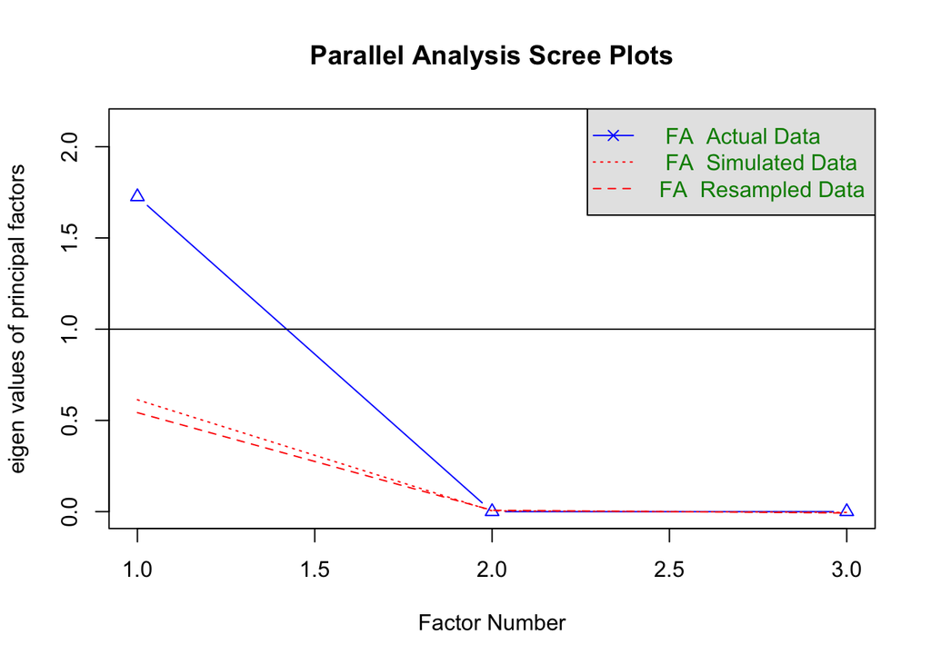

```
## Parallel analysis suggests that the number of factors =  1  and the number of components =  NA
```

```
## Factor Analysis using method =  minres
## Call: fa(r = d_pca_CIMbenefits, nfactors = 1, rotate = "Varimax", fm = "minres")
## Standardized loadings (pattern matrix) based upon correlation matrix
##                              MR1   h2   u2 com
## sr_16_hear_friends_talk     0.63 0.40 0.60   1
## sr_17_hear_media            0.74 0.54 0.46   1
## sr_18_hear_public_officials 0.88 0.78 0.22   1
##
##                 MR1
## SS loadings    1.73
## Proportion Var 0.58
##
## Mean item complexity =  1
## Test of the hypothesis that 1 factor is sufficient.
##
## The degrees of freedom for the null model are  3  and the objective function was  0.96 with Chi Square of  1005.49
## The degrees of freedom for the model are 0  and the objective function was  0
##
## The root mean square of the residuals (RMSR) is  0
## The df corrected root mean square of the residuals is  NA
##
## The harmonic number of observations is  1049 with the empirical chi square  0  with prob <  NA
## The total number of observations was  1055  with Likelihood Chi Square =  0  with prob <  NA
##
## Tucker Lewis Index of factoring reliability =  -Inf
## Fit based upon off diagonal values = 1
## Measures of factor score adequacy
##                                                    MR1
## Correlation of (regression) scores with factors   0.92
## Multiple R square of scores with factors          0.84
## Minimum correlation of possible factor scores     0.69
```

```
##
## Loadings:
##                             MR1
## sr_16_hear_friends_talk     0.633
## sr_17_hear_media            0.737
## sr_18_hear_public_officials 0.884
##
##                  MR1
## SS loadings    1.726
## Proportion Var 0.575
```

#### CIM - Benefits - Cronbach Alpha

```
##
## Reliability analysis
## Call: psych::alpha(x = d_pca_CIMbenefits, na.rm = TRUE, use = "pairwise")
##
##   raw_alpha std.alpha G6(smc) average_r S/N   ase mean  sd median_r
##       0.79      0.79    0.73      0.56 3.8 0.011  2.4 1.1     0.56
##
##  lower alpha upper     95% confidence boundaries
## 0.77 0.79 0.81
##
##  Reliability if an item is dropped:
##                             raw_alpha std.alpha G6(smc) average_r S/N alpha se
## sr_16_hear_friends_talk          0.79      0.79    0.65      0.65 3.7    0.013
## sr_17_hear_media                 0.72      0.72    0.56      0.56 2.5    0.017
## sr_18_hear_public_officials      0.63      0.64    0.47      0.47 1.8    0.022
##                             var.r med.r
## sr_16_hear_friends_talk        NA  0.65
## sr_17_hear_media               NA  0.56
## sr_18_hear_public_officials    NA  0.47
##
##  Item statistics
##                                n raw.r std.r r.cor r.drop mean  sd
## sr_16_hear_friends_talk     1052  0.79  0.80  0.63   0.56  2.0 1.2
## sr_17_hear_media            1051  0.86  0.84  0.72   0.64  2.8 1.4
## sr_18_hear_public_officials 1050  0.88  0.88  0.80   0.71  2.3 1.3
##
## Non missing response frequency for each item
##                                1    2    3    4    5 miss
## sr_16_hear_friends_talk     0.47 0.26 0.13 0.09 0.04    0
## sr_17_hear_media            0.22 0.24 0.18 0.20 0.15    0
## sr_18_hear_public_officials 0.33 0.28 0.16 0.16 0.06    0
```

$$\\[.05in]$$

### CIM - Perceived Risk

*“How important is each of the following issues to you today?”*  
*“How important is the issue of climate change to you personally?”*  
*“How worried are you about climate change?”*  
*“How much do you think climate change will harm you personally?”*  
*“How much do you think climate change will harm future generations of people?”*

NOTE - removing #7 for now until I understand how to properly account for it.

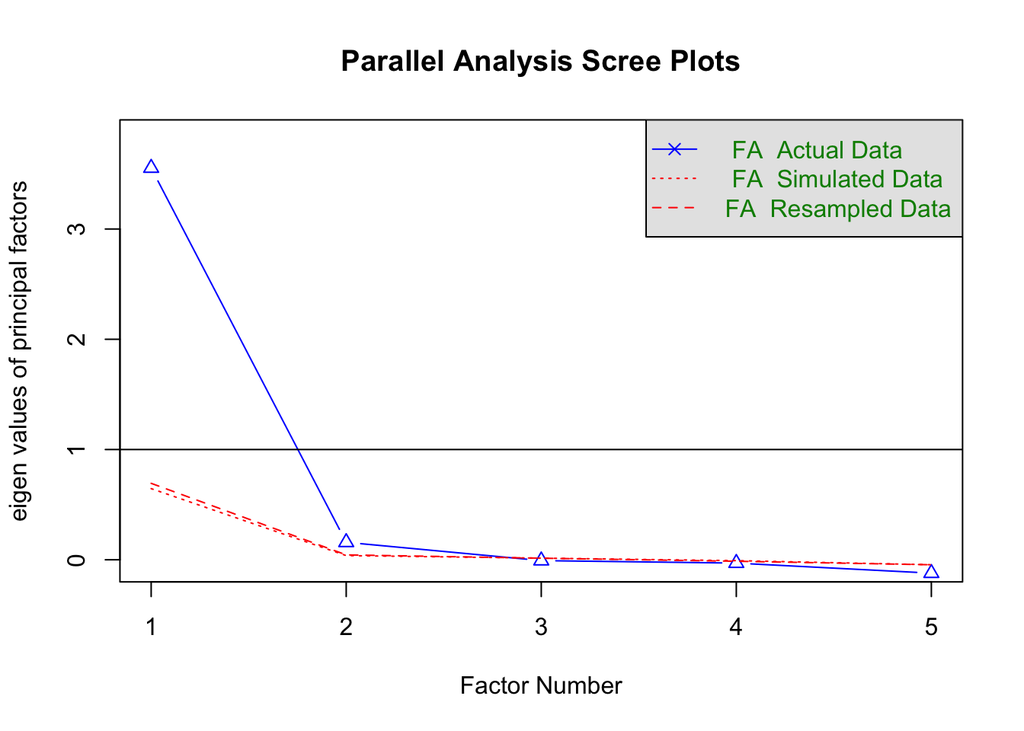

```
## Parallel analysis suggests that the number of factors =  2  and the number of components =  NA
```

```
## Factor Analysis using method =  minres
## Call: fa(r = d_pca_CIMperceivedrisk, nfactors = 2, rotate = "Varimax",
##     fm = "minres")
## Standardized loadings (pattern matrix) based upon correlation matrix
##                                 MR1  MR2   h2     u2 com
## sr_3b_importance_climatechange 0.72 0.44 0.71 0.2892 1.6
## sr_8_importance_personally     0.87 0.40 0.92 0.0836 1.4
## sr_9_worried                   0.77 0.43 0.77 0.2258 1.6
## sr_10_harm_you_personally      0.50 0.58 0.59 0.4133 2.0
## sr_11_harm_future_generations  0.37 0.93 1.00 0.0029 1.3
##
##                        MR1  MR2
## SS loadings           2.26 1.73
## Proportion Var        0.45 0.35
## Cumulative Var        0.45 0.80
## Proportion Explained  0.57 0.43
## Cumulative Proportion 0.57 1.00
##
## Mean item complexity =  1.6
## Test of the hypothesis that 2 factors are sufficient.
##
## The degrees of freedom for the null model are  10  and the objective function was  3.96 with Chi Square of  4158.92
## The degrees of freedom for the model are 1  and the objective function was  0.01
##
## The root mean square of the residuals (RMSR) is  0.01
## The df corrected root mean square of the residuals is  0.03
##
## The harmonic number of observations is  1046 with the empirical chi square  1.42  with prob <  0.23
## The total number of observations was  1055  with Likelihood Chi Square =  13.27  with prob <  0.00027
##
## Tucker Lewis Index of factoring reliability =  0.97
## RMSEA index =  0.108  and the 90 % confidence intervals are  0.062 0.163
## BIC =  6.3
## Fit based upon off diagonal values = 1
## Measures of factor score adequacy
##                                                    MR1  MR2
## Correlation of (regression) scores with factors   0.95 0.99
## Multiple R square of scores with factors          0.90 0.98
## Minimum correlation of possible factor scores     0.79 0.95
```

```
##
## Loadings:
##                                MR1   MR2
## sr_3b_importance_climatechange 0.721 0.438
## sr_8_importance_personally     0.869 0.401
## sr_9_worried                   0.770 0.426
## sr_10_harm_you_personally      0.503 0.577
## sr_11_harm_future_generations  0.373 0.926
##
##                  MR1   MR2
## SS loadings    2.260 1.725
## Proportion Var 0.452 0.345
## Cumulative Var 0.452 0.797
```

#### CIM - Perceived Risk - 1st factor (Personal) - Cronbach Alpha

```
##
## Reliability analysis
## Call: psych::alpha(x = d_pca_CIMperceivedriskpersonal, na.rm = TRUE,
##     use = "pairwise")
##
##   raw_alpha std.alpha G6(smc) average_r S/N    ase mean  sd median_r
##        0.9      0.91    0.89      0.72  10 0.0047  2.5 1.1     0.72
##
##  lower alpha upper     95% confidence boundaries
## 0.9 0.9 0.91
##
##  Reliability if an item is dropped:
##                                raw_alpha std.alpha G6(smc) average_r  S/N
## sr_3b_importance_climatechange      0.88      0.88    0.85      0.72  7.6
## sr_8_importance_personally          0.84      0.85    0.80      0.66  5.8
## sr_9_worried                        0.87      0.87    0.84      0.70  6.8
## sr_10_harm_you_personally           0.91      0.92    0.89      0.80 11.6
##                                alpha se  var.r med.r
## sr_3b_importance_climatechange   0.0065 0.0113  0.69
## sr_8_importance_personally       0.0082 0.0063  0.63
## sr_9_worried                     0.0068 0.0100  0.69
## sr_10_harm_you_personally        0.0044 0.0018  0.80
##
##  Item statistics
##                                   n raw.r std.r r.cor r.drop mean   sd
## sr_3b_importance_climatechange 1051  0.90  0.89  0.84   0.80  2.5 1.37
## sr_8_importance_personally     1053  0.94  0.94  0.93   0.88  2.7 1.26
## sr_9_worried                   1047  0.89  0.91  0.87   0.83  2.1 0.98
## sr_10_harm_you_personally      1051  0.82  0.82  0.72   0.69  2.7 1.19
##
## Non missing response frequency for each item
##                                   1    2    3    4    5 miss
## sr_3b_importance_climatechange 0.31 0.22 0.23 0.10 0.13 0.00
## sr_8_importance_personally     0.22 0.23 0.30 0.14 0.11 0.00
## sr_9_worried                   0.30 0.39 0.18 0.13 0.00 0.01
## sr_10_harm_you_personally      0.16 0.30 0.28 0.17 0.09 0.00
```

#### CIM - Perceived Risk - Descriptive stats on single-item variables

```r
mean(d_accept$sr_11_harm_future_generations, na.rm=TRUE)
```

```
## [1] 2.254528
```

```r
sd(d_accept$sr_11_harm_future_generations, na.rm=TRUE)
```

```
## [1] 1.333308
```

```r
mean(d_accept$sr_7_believe_about_climate_change, na.rm=TRUE)
```

```
## [1] 3.342884
```

```r
sd(d_accept$sr_7_believe_about_climate_change, na.rm=TRUE)
```

```
## [1] 1.148573
```

$$\\[.05in]$$

### Efficacy

*“Below is a list of actions that individuals could take to reduce climate change. If YOU took these actions, how effective would each be for reducing climate change?”*  
*“Below are some public and private organizations who make decisions that have an impact on climate change. In general, how COMPETENT is each in addressing climate change?”*  
*“In general, how RESPONSIVE is each in addressing climate change?”*  
*“How much do you agree that each type of organization is generally IN A POSITION TO EFFECTIVELY reduce climate change?”*

Three-factor solution:  
1. 1-item variable: 21a: Is contacting elected reps an effective action?  
2. Multi-item composite variable: All types (fed, state, business, ngo) are in a position to effect change  
3. Multi-item composite variable: The competency and responsiveness of fed, state, and business  
4. 2-item composite variable: The competency and responsiveness of ngo only

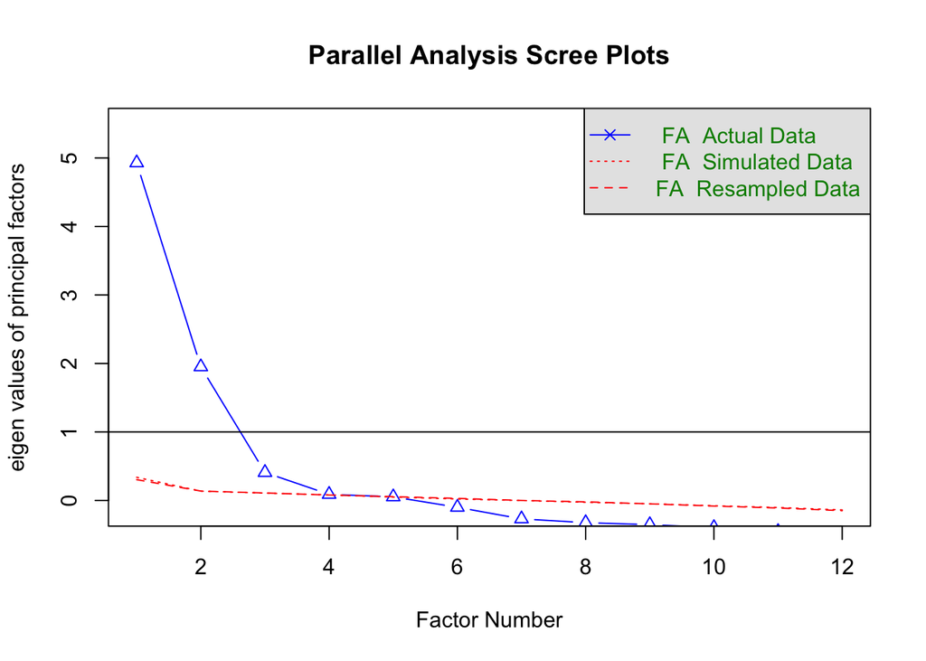

```
## Parallel analysis suggests that the number of factors =  3  and the number of components =  NA
```

```
## Factor Analysis using method =  minres
## Call: fa(r = d_pca_efficacysecond, nfactors = 3, rotate = "Varimax",
##     fm = "minres")
## Standardized loadings (pattern matrix) based upon correlation matrix
##                              MR1  MR2  MR3   h2   u2 com
## sr_27a_competent_fed        0.02 0.86 0.07 0.74 0.26 1.0
## sr_27b_competent_state      0.27 0.59 0.32 0.53 0.47 2.0
## sr_27c_competent_business   0.17 0.55 0.51 0.59 0.41 2.2
## sr_27d_competent_ngo        0.40 0.19 0.66 0.63 0.37 1.8
## sr_28a_responsive_fed      -0.04 0.82 0.11 0.68 0.32 1.0
## sr_28b_responsive_state     0.21 0.65 0.34 0.58 0.42 1.8
## sr_28c_responsive_business  0.15 0.54 0.57 0.63 0.37 2.1
## sr_28d_responsive_ngo       0.31 0.18 0.73 0.67 0.33 1.5
## sr_29a_effective_fed        0.87 0.11 0.05 0.77 0.23 1.0
## sr_29b_effective_state      0.93 0.10 0.13 0.89 0.11 1.1
## sr_29c_effective_business   0.84 0.00 0.26 0.77 0.23 1.2
## sr_29d_effective_ngo        0.77 0.00 0.32 0.69 0.31 1.3
##
##                        MR1  MR2  MR3
## SS loadings           3.34 2.85 1.97
## Proportion Var        0.28 0.24 0.16
## Cumulative Var        0.28 0.52 0.68
## Proportion Explained  0.41 0.35 0.24
## Cumulative Proportion 0.41 0.76 1.00
##
## Mean item complexity =  1.5
## Test of the hypothesis that 3 factors are sufficient.
##
## The degrees of freedom for the null model are  66  and the objective function was  9.14 with Chi Square of  9594.5
## The degrees of freedom for the model are 33  and the objective function was  1.26
##
## The root mean square of the residuals (RMSR) is  0.05
## The df corrected root mean square of the residuals is  0.07
##
## The harmonic number of observations is  1049 with the empirical chi square  297.12  with prob <  3e-44
## The total number of observations was  1055  with Likelihood Chi Square =  1318.66  with prob <  4.4e-256
##
## Tucker Lewis Index of factoring reliability =  0.73
## RMSEA index =  0.192  and the 90 % confidence intervals are  0.183 0.201
## BIC =  1088.94
## Fit based upon off diagonal values = 0.99
## Measures of factor score adequacy
##                                                    MR1  MR2  MR3
## Correlation of (regression) scores with factors   0.97 0.93 0.87
## Multiple R square of scores with factors          0.93 0.86 0.76
## Minimum correlation of possible factor scores     0.86 0.72 0.51
```

```
##
## Loadings:
##                            MR1    MR2    MR3
## sr_27a_competent_fed               0.855
## sr_27b_competent_state             0.595  0.324
## sr_27c_competent_business          0.547  0.508
## sr_27d_competent_ngo        0.401         0.656
## sr_28a_responsive_fed              0.817
## sr_28b_responsive_state            0.647  0.345
## sr_28c_responsive_business         0.536  0.567
## sr_28d_responsive_ngo       0.312         0.733
## sr_29a_effective_fed        0.868
## sr_29b_effective_state      0.931
## sr_29c_effective_business   0.840
## sr_29d_effective_ngo        0.766         0.320
##
##                  MR1   MR2   MR3
## SS loadings    3.340 2.847 1.974
## Proportion Var 0.278 0.237 0.165
## Cumulative Var 0.278 0.516 0.680
```

#### Efficacy - 1st variable (contacting elected officials an effective action?)

```
## [1] 2.714829
```

```
## [1] 1.067845
```

#### Efficacy - 2nd Factor (All types’ ability to effect change) - Cronbach Alpha

```
##
## Reliability analysis
## Call: psych::alpha(x = d_pca_efficacyeffectchangesecond, na.rm = TRUE,
##     use = "pairwise")
##
##   raw_alpha std.alpha G6(smc) average_r S/N    ase mean  sd median_r
##       0.93      0.93    0.92      0.76  13 0.0038  3.4 1.1     0.76
##
##  lower alpha upper     95% confidence boundaries
## 0.92 0.93 0.93
##
##  Reliability if an item is dropped:
##                           raw_alpha std.alpha G6(smc) average_r  S/N alpha se
## sr_29a_effective_fed           0.91      0.91    0.87      0.77 10.1   0.0048
## sr_29b_effective_state         0.89      0.89    0.85      0.73  7.9   0.0062
## sr_29c_effective_business      0.90      0.90    0.87      0.75  8.9   0.0055
## sr_29d_effective_ngo           0.92      0.92    0.89      0.79 11.6   0.0043
##                             var.r med.r
## sr_29a_effective_fed      0.00054  0.78
## sr_29b_effective_state    0.00399  0.75
## sr_29c_effective_business 0.00898  0.75
## sr_29d_effective_ngo      0.00238  0.79
##
##  Item statistics
##                              n raw.r std.r r.cor r.drop mean  sd
## sr_29a_effective_fed      1053  0.90  0.90  0.86   0.81  3.4 1.3
## sr_29b_effective_state    1054  0.93  0.93  0.92   0.88  3.5 1.2
## sr_29c_effective_business 1052  0.91  0.91  0.88   0.84  3.5 1.2
## sr_29d_effective_ngo      1053  0.87  0.88  0.82   0.78  3.4 1.1
##
## Non missing response frequency for each item
##                              1    2    3    4    5 miss
## sr_29a_effective_fed      0.12 0.07 0.31 0.25 0.25    0
## sr_29b_effective_state    0.10 0.07 0.34 0.29 0.21    0
## sr_29c_effective_business 0.09 0.06 0.36 0.27 0.22    0
## sr_29d_effective_ngo      0.09 0.07 0.40 0.29 0.15    0
```

#### Efficacy - 3rd Factor (Competency & Responsiveness of Fed, State, and Business) - Cronbach Alpha

```
##
## Reliability analysis
## Call: psych::alpha(x = d_pca_efficacycompetencyresponsivesecond, na.rm = TRUE,
##     use = "pairwise")
##
##   raw_alpha std.alpha G6(smc) average_r S/N    ase mean   sd median_r
##       0.88      0.88    0.91      0.55 7.4 0.0058  2.8 0.87     0.55
##
##  lower alpha upper     95% confidence boundaries
## 0.87 0.88 0.89
##
##  Reliability if an item is dropped:
##                            raw_alpha std.alpha G6(smc) average_r S/N alpha se
## sr_27a_competent_fed            0.86      0.86    0.87      0.55 6.1   0.0071
## sr_27b_competent_state          0.86      0.86    0.87      0.56 6.4   0.0067
## sr_27c_competent_business       0.86      0.86    0.89      0.56 6.3   0.0069
## sr_28a_responsive_fed           0.86      0.86    0.87      0.56 6.3   0.0069
## sr_28b_responsive_state         0.85      0.86    0.86      0.54 5.9   0.0071
## sr_28c_responsive_business      0.86      0.86    0.88      0.55 6.2   0.0069
##                             var.r med.r
## sr_27a_competent_fed       0.0106  0.55
## sr_27b_competent_state     0.0104  0.54
## sr_27c_competent_business  0.0144  0.54
## sr_28a_responsive_fed      0.0083  0.55
## sr_28b_responsive_state    0.0121  0.54
## sr_28c_responsive_business 0.0133  0.55
##
##  Item statistics
##                               n raw.r std.r r.cor r.drop mean  sd
## sr_27a_competent_fed       1054  0.82  0.80  0.77   0.71  2.5 1.2
## sr_27b_competent_state     1053  0.77  0.78  0.74   0.67  2.9 1.0
## sr_27c_competent_business  1053  0.78  0.78  0.73   0.68  2.9 1.0
## sr_28a_responsive_fed      1051  0.80  0.78  0.76   0.69  2.5 1.2
## sr_28b_responsive_state    1049  0.81  0.82  0.79   0.72  2.9 1.1
## sr_28c_responsive_business 1052  0.78  0.79  0.74   0.68  2.9 1.0
##
## Non missing response frequency for each item
##                               1    2    3    4    5 miss
## sr_27a_competent_fed       0.28 0.19 0.35 0.14 0.06 0.00
## sr_27b_competent_state     0.13 0.18 0.42 0.22 0.05 0.00
## sr_27c_competent_business  0.12 0.16 0.45 0.20 0.06 0.00
## sr_28a_responsive_fed      0.29 0.18 0.35 0.13 0.05 0.00
## sr_28b_responsive_state    0.13 0.18 0.42 0.22 0.05 0.01
## sr_28c_responsive_business 0.13 0.15 0.46 0.21 0.05 0.00
```

#### Efficacy - 4th Factor (Competency & Responsiveness of NGO) - Correlation

```
##
##  Spearman's rank correlation rho
##
## data:  d_accept$sr_27d_competent_ngo and d_accept$sr_28d_responsive_ngo
## S = 63414925, p-value < 2.2e-16
## alternative hypothesis: true rho is not equal to 0
## sample estimates:
##       rho
## 0.6627197
```

```
## [1] 3.14381
```

```
## [1] 0.9972721
```

```
## [1] 3.165392
```

```
## [1] 0.9685915
```

Correlation test of the competency and responsiveness scores for NGOs shows moderate positive correlation. Spearman’s rho is 0.6627197 with a p-value of 1.198006810^{-132}.

$$\\[.05in]$$

### TPB Behavioral Attitude

*“For me, contacting (writing letters, emailing, phoning my elected representatives in Congress to urge action on climate change on a regular basis during the next year would be …”*

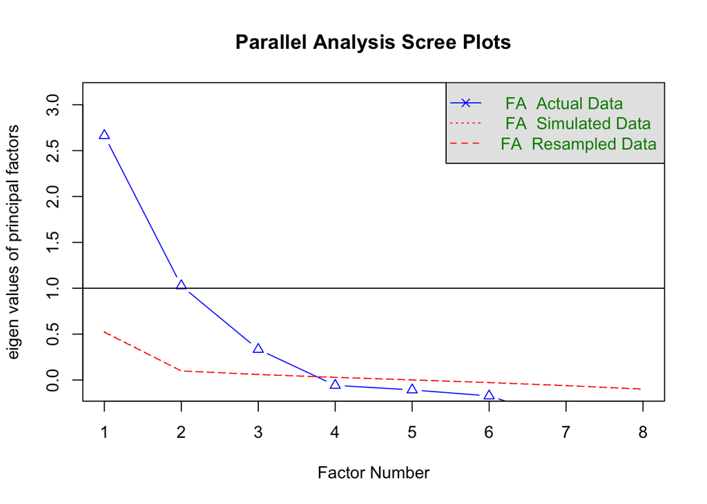

```
## Parallel analysis suggests that the number of factors =  3  and the number of components =  NA
```

```
## Factor Analysis using method =  minres
## Call: fa(r = ba2, nfactors = 3, rotate = "Varimax", fm = "minres")
## Standardized loadings (pattern matrix) based upon correlation matrix
##                                   MR1   MR2   MR3   h2   u2 com
## sr_32_contact_useful_reversed   -0.06  0.73 -0.05 0.54 0.46 1.0
## sr_33_contact_pleasant_reversed -0.03  0.80  0.00 0.64 0.36 1.0
## sr_34_contact_cool               0.50 -0.04  0.63 0.65 0.35 1.9
## sr_35_contact_easy               0.27  0.04  0.59 0.42 0.58 1.4
## sr_36_contact_exciting           0.38 -0.06  0.62 0.54 0.46 1.7
## sr_37_contact_foolish_reversed   0.04  0.62 -0.01 0.39 0.61 1.0
## sr_38_contact_admirable          0.93 -0.01  0.15 0.90 0.10 1.1
## sr_39_contact_good               0.83 -0.03  0.27 0.75 0.25 1.2
##
##                        MR1  MR2  MR3
## SS loadings           2.03 1.57 1.24
## Proportion Var        0.25 0.20 0.15
## Cumulative Var        0.25 0.45 0.60
## Proportion Explained  0.42 0.32 0.26
## Cumulative Proportion 0.42 0.74 1.00
##
## Mean item complexity =  1.3
## Test of the hypothesis that 3 factors are sufficient.
##
## The degrees of freedom for the null model are  28  and the objective function was  3.16 with Chi Square of  3317.94
## The degrees of freedom for the model are 7  and the objective function was  0.01
##
## The root mean square of the residuals (RMSR) is  0.01
## The df corrected root mean square of the residuals is  0.02
##
## The harmonic number of observations is  1032 with the empirical chi square  5.36  with prob <  0.62
## The total number of observations was  1055  with Likelihood Chi Square =  13.25  with prob <  0.066
##
## Tucker Lewis Index of factoring reliability =  0.992
## RMSEA index =  0.029  and the 90 % confidence intervals are  0 0.053
## BIC =  -35.48
## Fit based upon off diagonal values = 1
## Measures of factor score adequacy
##                                                    MR1  MR2  MR3
## Correlation of (regression) scores with factors   0.95 0.88 0.81
## Multiple R square of scores with factors          0.89 0.78 0.66
## Minimum correlation of possible factor scores     0.79 0.56 0.32
```

```
##
## Loadings:
##                                 MR1    MR2    MR3
## sr_32_contact_useful_reversed           0.733
## sr_33_contact_pleasant_reversed         0.798
## sr_34_contact_cool               0.502         0.633
## sr_35_contact_easy                             0.592
## sr_36_contact_exciting           0.379         0.623
## sr_37_contact_foolish_reversed          0.620
## sr_38_contact_admirable          0.934
## sr_39_contact_good               0.825
##
##                  MR1   MR2   MR3
## SS loadings    2.027 1.567 1.236
## Proportion Var 0.253 0.196 0.155
## Cumulative Var 0.253 0.449 0.604
```

#### TPB Behavioral Attitude - 1st factor - Correlation

```
##
##  Spearman's rank correlation rho
##
## data:  d_accept$sr_38_contact_admirable and d_accept$sr_39_contact_good
## S = 35101796, p-value < 2.2e-16
## alternative hypothesis: true rho is not equal to 0
## sample estimates:
##       rho
## 0.8049981
```

#### TPB Behavioral Attitude - 2nd factor - Cronbach Alpha

```
##
## Reliability analysis
## Call: psych::alpha(x = d_pca_behavioralattitude2, na.rm = TRUE, use = "pairwise")
##
##   raw_alpha std.alpha G6(smc) average_r S/N   ase mean  sd median_r
##       0.75      0.76    0.68      0.51 3.1 0.013  3.4 1.6     0.49
##
##  lower alpha upper     95% confidence boundaries
## 0.73 0.75 0.78
##
##  Reliability if an item is dropped:
##                                 raw_alpha std.alpha G6(smc) average_r S/N
## sr_32_contact_useful_reversed        0.66      0.66    0.49      0.49 2.0
## sr_33_contact_pleasant_reversed      0.61      0.62    0.45      0.45 1.6
## sr_37_contact_foolish_reversed       0.73      0.74    0.59      0.59 2.8
##                                 alpha se var.r med.r
## sr_32_contact_useful_reversed      0.021    NA  0.49
## sr_33_contact_pleasant_reversed    0.023    NA  0.45
## sr_37_contact_foolish_reversed     0.016    NA  0.59
##
##  Item statistics
##                                    n raw.r std.r r.cor r.drop mean  sd
## sr_32_contact_useful_reversed   1048  0.85  0.83  0.69   0.60  3.3 2.1
## sr_33_contact_pleasant_reversed 1048  0.84  0.84  0.73   0.64  3.5 1.8
## sr_37_contact_foolish_reversed  1041  0.77  0.79  0.60   0.53  3.2 1.8
##
## Non missing response frequency for each item
##                                    0    1    2    3    4    5    6 miss
## sr_32_contact_useful_reversed   0.20 0.05 0.07 0.12 0.24 0.10 0.22 0.01
## sr_33_contact_pleasant_reversed 0.12 0.04 0.08 0.14 0.34 0.11 0.16 0.01
## sr_37_contact_foolish_reversed  0.12 0.07 0.12 0.19 0.28 0.11 0.11 0.01
```

#### TPB Behavioral Attitude - 3rd factor - Cronbach Alpha

```
##
## Reliability analysis
## Call: psych::alpha(x = d_pca_behavioralattitude3, na.rm = TRUE, use = "pairwise")
##
##   raw_alpha std.alpha G6(smc) average_r S/N   ase mean  sd median_r
##       0.76      0.76    0.69      0.52 3.2 0.013  3.1 1.4     0.51
##
##  lower alpha upper     95% confidence boundaries
## 0.74 0.76 0.79
##
##  Reliability if an item is dropped:
##                        raw_alpha std.alpha G6(smc) average_r S/N alpha se var.r
## sr_34_contact_cool          0.64      0.64    0.47      0.47 1.8    0.022    NA
## sr_35_contact_easy          0.74      0.74    0.58      0.58 2.8    0.016    NA
## sr_36_contact_exciting      0.67      0.67    0.51      0.51 2.0    0.020    NA
##                        med.r
## sr_34_contact_cool      0.47
## sr_35_contact_easy      0.58
## sr_36_contact_exciting  0.51
##
##  Item statistics
##                           n raw.r std.r r.cor r.drop mean  sd
## sr_34_contact_cool     1041  0.84  0.85  0.73   0.63  2.9 1.7
## sr_35_contact_easy     1041  0.81  0.80  0.62   0.55  3.0 1.8
## sr_36_contact_exciting 1038  0.82  0.83  0.70   0.60  3.4 1.7
##
## Non missing response frequency for each item
##                           0    1    2    3    4    5    6 miss
## sr_34_contact_cool     0.09 0.15 0.13 0.33 0.12 0.09 0.10 0.01
## sr_35_contact_easy     0.10 0.15 0.11 0.25 0.15 0.13 0.11 0.01
## sr_36_contact_exciting 0.05 0.10 0.10 0.30 0.18 0.13 0.14 0.02
```

$$\\[.05in]$$
#### Perceived Behavioral Control - correlation

```
## [1] 3.024015
```

```
## [1] 1.811395
```

### Perceived Behavioral Control

```
##
##  Spearman's rank correlation rho
##
## data:  d_accept$sr_30_easy_to_call and d_accept$sr_31_able_to_call
## S = 69547802, p-value < 2.2e-16
## alternative hypothesis: true rho is not equal to 0
## sample estimates:
##       rho
## 0.6405596
```

The two measures of perceived behavioral control show a moderate positive relationship, just barely under the .65 rule of thumb. Spearman’s rho is 0.6405596 with a p-value of 1.878955810^{-122}. This is not a strong enough correlation to justify a composite variable of the two items, so they will stay separate.

$$\\[.05in]$$

### Worldviews

We decided these will be kept as-is.

```
##  sr_41a_right_to_modify sr_41b_laws_of_nature sr_41c_ingenuity sr_41d_impotent
##  Min.   :1.000          Min.   :1.000         Min.   :1.000    Min.   :1.000
##  1st Qu.:2.000          1st Qu.:3.000         1st Qu.:3.000    1st Qu.:2.000
##  Median :3.000          Median :4.000         Median :3.000    Median :3.000
##  Mean   :2.842          Mean   :3.885         Mean   :3.137    Mean   :2.834
##  3rd Qu.:4.000          3rd Qu.:5.000         3rd Qu.:4.000    3rd Qu.:4.000
##  Max.   :5.000          Max.   :5.000         Max.   :5.000    Max.   :5.000
##  NA's   :3              NA's   :5             NA's   :5        NA's   :2
##  sr_41e_govt_do_more sr_41f_equity
##  Min.   :1.000       Min.   :1.000
##  1st Qu.:3.000       1st Qu.:3.000
##  Median :4.000       Median :3.000
##  Mean   :3.512       Mean   :3.377
##  3rd Qu.:4.000       3rd Qu.:4.000
##  Max.   :5.000       Max.   :5.000
##  NA's   :6           NA's   :3
```

```
## sr_41a_right_to_modify  sr_41b_laws_of_nature       sr_41c_ingenuity
##              1.1532464              0.9680581              1.0598179
##        sr_41d_impotent    sr_41e_govt_do_more          sr_41f_equity
##              1.0917581              1.1811582              1.1710030
```

$$\\[.05in]$$

# Creating PCA variables for regression

#### note: leaving this out of the markup file unless you’d like to review the variable creation code

$$\\[.05in]$$

# Creating dummy categorical variables

#### note: leaving this out of the markup file unless you’d like to review the variable creation code

$$\\[.05in]$$
# Ordinal logistic regression model

```r
library(MASS)

# Convert RV (12a) past contact to a factor and assign labels
d_accept$sr_12a_actions_contacted_officials_factor <- factor(d_accept$sr_12a_actions_contacted_officials)
levels(d_accept$sr_12a_actions_contacted_officials_factor) <- list("NoContact"="1", "Once"="2", "MoreOnce"="3")

# d_accept %>% dplyr::select(sr_12a_actions_contacted_officials_factor, sr_12a_actions_contacted_officials) %>% head(200)

# Build ordinal logistic regression model
ord_reg_model <- polr(d_accept$sr_12a_actions_contacted_officials_factor ~
                        descdynamicnorms_comp + sr_19a_contacting_officials__parents + desccontactnorms_fam_comp + desccontactnorms_nf_comp + sr_20a_rolemodels_parents + descrolemodelnorms_fam_comp + descrolemodelnorms_nf_comp + sr_22a_expect_contact_parents + injunctcontactnorms_fam_comp + injunctcontactnorms_nf_comp + injunctmotivation_fam_comp + injunctmotivation_nf_comp + cimbenefits_comp + cimperceivedrisk_comp + sr_7_believe_about_climate_change + sr_11_harm_future_generations + sr_21a_effective_actions_contacting_officials + efficacy_effectiveness_comp + efficacy_fedstatebusiness_competresp_comp + efficacy_ngo_competresp_comp + behatt_admirablegood_comp + behatt_usefulpleasantsensible_comp + behatt_coolexcitingeasy_comp + sr_30_easy_to_call + sr_31_able_to_call + sr_41a_right_to_modify + sr_41b_laws_of_nature + sr_41c_ingenuity + sr_41d_impotent + sr_41e_govt_do_more + sr_41f_equity + age + gender_male + gender_other + gender_prefernottosay + sr_56_marital_status_marriedpartner + sr_56_marital_status_divorcedseparated + sr_56_marital_status_widowed + sr_57i_dependents + sr_57j_adultchildren + sr_61_education_highschooldegree + sr_61_education_somecollege + sr_61_education_associatedegree + sr_61_education_bachelordegree + sr_61_education_gradorprofdegree + sr_71_employment_status_workparttime + sr_71_employment_status_homemaker + sr_71_employment_status_retired + sr_71_employment_status_student + sr_71_employment_status_unemployed + sr_72_income_25to49k + sr_72_income_50to74k + sr_72_income_75to99k + sr_72_income_100to149k + sr_72_income_150to199k + sr_72_income_200to249k + sr_72_income_over250k + sr_72_income_prefernottoanswer + race_white_dumvar + sr_78_political_affiliation_Rep + sr_78_political_affiliation_Ind + sr_78_political_affiliation_Green + sr_78_political_affiliation_Libertarian + sr_78_political_affiliation_NoParty + sr_79_political_leaning_SomeLib + sr_79_political_leaning_Moderate + sr_79_political_leaning_SomeConservative + sr_79_political_leaning_VeryConservative , data = d_accept, Hess = T)

summary(ord_reg_model)
```

```
## Call:
## polr(formula = d_accept$sr_12a_actions_contacted_officials_factor ~
##     descdynamicnorms_comp + sr_19a_contacting_officials__parents +
##         desccontactnorms_fam_comp + desccontactnorms_nf_comp +
##         sr_20a_rolemodels_parents + descrolemodelnorms_fam_comp +
##         descrolemodelnorms_nf_comp + sr_22a_expect_contact_parents +
##         injunctcontactnorms_fam_comp + injunctcontactnorms_nf_comp +
##         injunctmotivation_fam_comp + injunctmotivation_nf_comp +
##         cimbenefits_comp + cimperceivedrisk_comp + sr_7_believe_about_climate_change +
##         sr_11_harm_future_generations + sr_21a_effective_actions_contacting_officials +
##         efficacy_effectiveness_comp + efficacy_fedstatebusiness_competresp_comp +
##         efficacy_ngo_competresp_comp + behatt_admirablegood_comp +
##         behatt_usefulpleasantsensible_comp + behatt_coolexcitingeasy_comp +
##         sr_30_easy_to_call + sr_31_able_to_call + sr_41a_right_to_modify +
##         sr_41b_laws_of_nature + sr_41c_ingenuity + sr_41d_impotent +
##         sr_41e_govt_do_more + sr_41f_equity + age + gender_male +
##         gender_other + gender_prefernottosay + sr_56_marital_status_marriedpartner +
##         sr_56_marital_status_divorcedseparated + sr_56_marital_status_widowed +
##         sr_57i_dependents + sr_57j_adultchildren + sr_61_education_highschooldegree +
##         sr_61_education_somecollege + sr_61_education_associatedegree +
##         sr_61_education_bachelordegree + sr_61_education_gradorprofdegree +
##         sr_71_employment_status_workparttime + sr_71_employment_status_homemaker +
##         sr_71_employment_status_retired + sr_71_employment_status_student +
##         sr_71_employment_status_unemployed + sr_72_income_25to49k +
##         sr_72_income_50to74k + sr_72_income_75to99k + sr_72_income_100to149k +
##         sr_72_income_150to199k + sr_72_income_200to249k + sr_72_income_over250k +
##         sr_72_income_prefernottoanswer + race_white_dumvar +
##         sr_78_political_affiliation_Rep + sr_78_political_affiliation_Ind +
##         sr_78_political_affiliation_Green + sr_78_political_affiliation_Libertarian +
##         sr_78_political_affiliation_NoParty + sr_79_political_leaning_SomeLib +
##         sr_79_political_leaning_Moderate + sr_79_political_leaning_SomeConservative +
##         sr_79_political_leaning_VeryConservative, data = d_accept,
##     Hess = T)
##
## Coefficients:
##                                                    Value Std. Error    t value
## descdynamicnorms_comp                          -0.101685  2.763e-01 -3.680e-01
## sr_19a_contacting_officials__parents            0.357156  1.643e-01  2.174e+00
## desccontactnorms_fam_comp                      -0.174007  2.022e-01 -8.606e-01
## desccontactnorms_nf_comp                        0.455849  2.508e-01  1.818e+00
```

[output cut: 58 more lines]

```
## sr_78_political_affiliation_Libertarian        -0.443730  1.499e+00 -2.961e-01
## sr_78_political_affiliation_NoParty             0.724476  7.500e-01  9.660e-01
## sr_79_political_leaning_SomeLib                 0.366692  5.736e-01  6.393e-01
## sr_79_political_leaning_Moderate                0.127865  5.677e-01  2.252e-01
## sr_79_political_leaning_SomeConservative       -0.048785  6.452e-01 -7.561e-02
## sr_79_political_leaning_VeryConservative        0.131423  6.733e-01  1.952e-01
##
## Intercepts:
##                Value         Std. Error    t value
## NoContact|Once -2.349000e+00  2.542700e+00 -9.238000e-01
## Once|MoreOnce  -5.711000e-01  2.538900e+00 -2.249000e-01
##
## Residual Deviance: 423.6624
## AIC: 563.6624
## (427 observations deleted due to missingness)
```

```r
# Analyze p-values, combine back into summary table
ctable <- coef(summary(ord_reg_model))
p <- pnorm(abs(ctable[, "t value"]), lower.tail = FALSE) * 2
ctable <- cbind(ctable, "p value" = p)
print(ctable)
```

```
##                                                       Value   Std. Error
## descdynamicnorms_comp                          -0.101685149 2.763475e-01
## sr_19a_contacting_officials__parents            0.357156193 1.642638e-01
## desccontactnorms_fam_comp                      -0.174006985 2.021988e-01
## desccontactnorms_nf_comp                        0.455848581 2.508028e-01
## sr_20a_rolemodels_parents                       0.079319532 1.665453e-01
## descrolemodelnorms_fam_comp                    -0.110822686 2.299565e-01
## descrolemodelnorms_nf_comp                     -0.275828580 2.542632e-01
## sr_22a_expect_contact_parents                  -0.104689280 1.927618e-01
## injunctcontactnorms_fam_comp                    0.897102824 2.714944e-01
## injunctcontactnorms_nf_comp                    -0.561237106 3.009291e-01
## injunctmotivation_fam_comp                     -0.213968982 1.808514e-01
## injunctmotivation_nf_comp                       0.124901997 1.960703e-01
## cimbenefits_comp                                0.562979137 1.692201e-01
## cimperceivedrisk_comp                          -1.498097388 3.101442e-01
## sr_7_believe_about_climate_change              -0.367777399 1.575246e-01
## sr_11_harm_future_generations                   0.449270866 1.941061e-01
## sr_21a_effective_actions_contacting_officials   0.599215758 2.092259e-01
## efficacy_effectiveness_comp                    -0.062793304 2.191262e-01
## efficacy_fedstatebusiness_competresp_comp      -0.153354568 2.591095e-01
## efficacy_ngo_competresp_comp                    0.294180511 2.413364e-01
## behatt_admirablegood_comp                       0.131197449 1.616542e-01
## behatt_usefulpleasantsensible_comp              0.199844080 1.314114e-01
## behatt_coolexcitingeasy_comp                   -0.149879191 1.634333e-01
## sr_30_easy_to_call                              0.023458291 1.365880e-01
## sr_31_able_to_call                              0.076192527 1.446573e-01
## sr_41a_right_to_modify                          0.004325443 1.638299e-01
## sr_41b_laws_of_nature                          -0.565311709 2.171626e-01
## sr_41c_ingenuity                               -0.413157829 1.898731e-01
## sr_41d_impotent                                 0.048294040 1.699524e-01
## sr_41e_govt_do_more                             0.264117423 2.085771e-01
## sr_41f_equity                                   0.067187959 2.208999e-01
## age                                            -0.029138950 1.392508e-02
## gender_male                                    -0.014323930 3.166346e-01
## gender_other                                    0.368029306 1.784160e+00
## gender_prefernottosay                          -0.400124217 1.418811e+00
## sr_56_marital_status_marriedpartner             0.430708095 3.944912e-01
## sr_56_marital_status_divorcedseparated          0.271089990 6.205305e-01
## sr_56_marital_status_widowed                   -0.452873555 1.005804e+00
## sr_57i_dependents                               0.028408485 3.841105e-02
```

[output cut: 87 more lines]

```
## sr_72_income_200to249k                         2.111651e-01 8.327584e-01
## sr_72_income_over250k                          1.078914e+00 2.806262e-01
## sr_72_income_prefernottoanswer                 3.616781e-01 7.175926e-01
## race_white_dumvar                             -5.755244e-01 5.649367e-01
## sr_78_political_affiliation_Rep               -1.569606e+00 1.165068e-01
## sr_78_political_affiliation_Ind               -1.220334e+00 2.223384e-01
## sr_78_political_affiliation_Green             -3.307131e-01 7.408612e-01
## sr_78_political_affiliation_Libertarian       -2.960896e-01 7.671616e-01
## sr_78_political_affiliation_NoParty            9.660324e-01 3.340280e-01
## sr_79_political_leaning_SomeLib                6.392554e-01 5.226568e-01
## sr_79_political_leaning_Moderate               2.252346e-01 8.217968e-01
## sr_79_political_leaning_SomeConservative      -7.560941e-02 9.397298e-01
## sr_79_political_leaning_VeryConservative       1.952025e-01 8.452344e-01
## NoContact|Once                                -9.238220e-01 3.555790e-01
## Once|MoreOnce                                 -2.249293e-01 8.220343e-01
```